# Math311_HW4

Jackson Evans

5/9/2021

7.1) a) There is a 95% chance that an interval contructed in this way will contain the mean milk production of cows, not that there is a 95% chance a cow produces between 22 and 30 kg of milk a day. b) The mean is either within or not within the range. There is a 95% chance an interval constructed in this way will contain the mean. c) We are not estimating a range of values for cow milk production, but finding a confidence interval for the mean. d) Our confidence interval estimates the mean for the whole population and takes into account variability of samples. The 95% refers to confidence intervals built in this way, not samples.

7.3) mu=185, sd=50 a)sample size 100, sample mean = 210. sd=50. Find a 90% CI for mean.

```r
#t- confidence interval
#90% CI
x_bar<-210
n<-100
t<-qt(0.05, n-1)
s<-50

#Lower bound
x_bar + t*s/sqrt(n)
```

```
## [1] 201.698
```

```r
#Upper bound
x_bar - t*s/sqrt(n)
```

```
## [1] 218.302
```

```r
#95% confidence interval, so our z score is 1.96.
#Our inequality is 50*1.96/sqrt(n)<10.
(50*1.96/10)^2
```

```
## [1] 96.04
```

So n>96.04. Therefore we should sample at least 97 people.

```r
#99% confidence interval, so our z score is 2.576.
#Our inequality is 50*2.576/sqrt(n)<10.
(50*2.576/10)^2
```

```
## [1] 165.8944
```

So n>165.8944. Therefore we should sample at least 166 people.

7.30) a)

```r
library(resampledata)
```

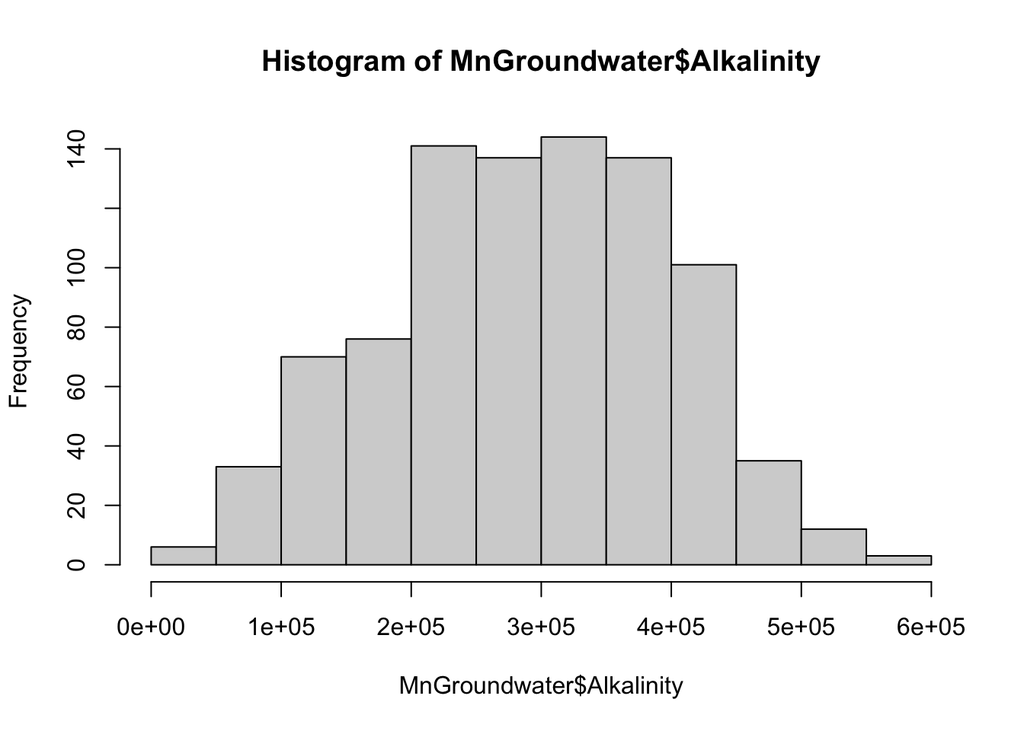

```r
hist(MnGroundwater$Alkalinity)
```

The distribution isn’t quite symmetric, and isn’t quite unimodal, but somewhat close to both. It seems to have large spread and a range of high frequency values. b)

```r
#t- confidence interval
#Say, 95% CI
x_bar<-mean(MnGroundwater$Alkalinity)
n<-length(MnGroundwater$Alkalinity)
t<-qt(0.025, n-1)
s<-sd(MnGroundwater$Alkalinity)

#Lower bound
x_bar + t*s/sqrt(n)
```

```
## [1] 283575.6
```

```r
#Upper bound
x_bar - t*s/sqrt(n)
```

```
## [1] 297789.8
```

Our 95% t-confidence interval is (283575.6, 297789.8).

```r
x_bar<-mean(MnGroundwater$Alkalinity)
n<-length(MnGroundwater$Alkalinity)
t<-qt(0.025, n-1)
s<-sd(MnGroundwater$Alkalinity)

#Bootstrap
ans<-NULL
set.seed(6399)
for(i in 1:10000){
  ans[i]<-mean(sample(MnGroundwater$Alkalinity,replace=TRUE))
}

#95%CI
quantile(ans, c(0.025, .975))
```

```
##     2.5%    97.5%
## 283627.7 297883.9
```

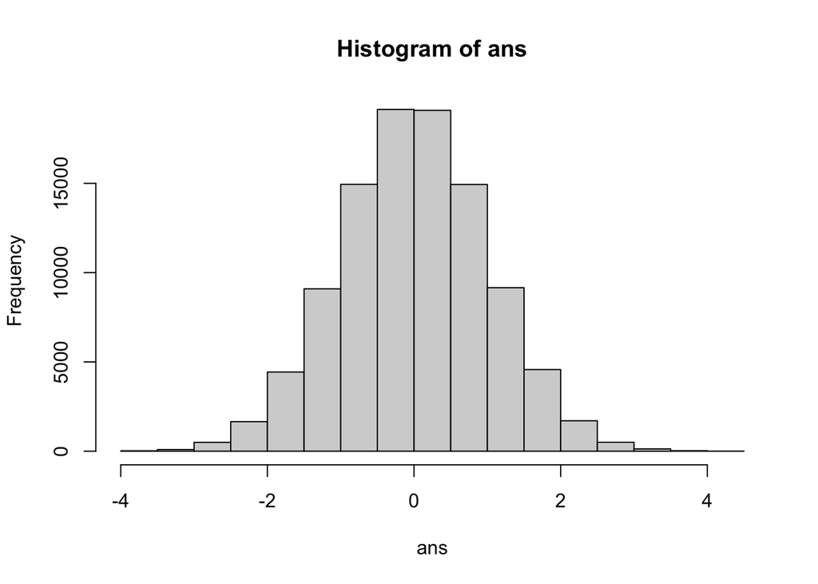

```r
#Bootstrap t-confidence interval
ans<-NULL
set.seed(12300)
for(i in 1:100000){
  samp<-sample(MnGroundwater$Alkalinity,replace=TRUE)
  ans[i]<-(mean(samp)-mean(MnGroundwater$Alkalinity))/(sd(samp)/sqrt(n))
}

#hist of ans
hist(ans)
```

```r
#Find out bootstrap t-interval
x_bar - quantile(ans,0.975)*s/sqrt(n)
```

```
##    97.5%
## 283522.5
```

```r
x_bar - quantile(ans,0.025)*s/sqrt(n)
```

```
##     2.5%
## 297780.4
```

8.3) a) H0, our null hypothesis: mu(body temperatures of children in Sodor) = 98.6 degrees. Ha, our alternative hypothesis: mu(body temperatures of children in Sodor) > 98.6 degrees. b)

```r
child_temp <- c(98,98.9,99,98.9,98.8,98.6,99.1,98.5,98.9,98.9,98.4,99,99.2,98.6,98.8,98.9,98.7)

#Conduct a formal hypothesis test for a single mean

#H0 = Average body temp is 98.6 degrees
#Let alpha = 0.05. So p-values of .05 are rare enough
#t=(x_bar-mu)/(s/sqrt(n))

#Let's conduct a formal hypothesis test for a single mean
t<-(mean(child_temp)-98.6)/(sd(child_temp)/sqrt(18))

#P(t<-3.17)
pt(t,17)*2
```

```
## [1] 1.980409
```

```r
#p-value is

#Let's do a t-test
t.test(child_temp, mu=98.6, alternative = "greater") #make sure alternative is greater, congruent with the alternative hypothesis in the prompt.
```

```
##
##  One Sample t-test
##
## data:  child_temp
## t = 2.5044, df = 16, p-value = 0.01173
## alternative hypothesis: true mean is greater than 98.6
## 95 percent confidence interval:
##  98.65345      Inf
## sample estimates:
## mean of x
##  98.77647
```

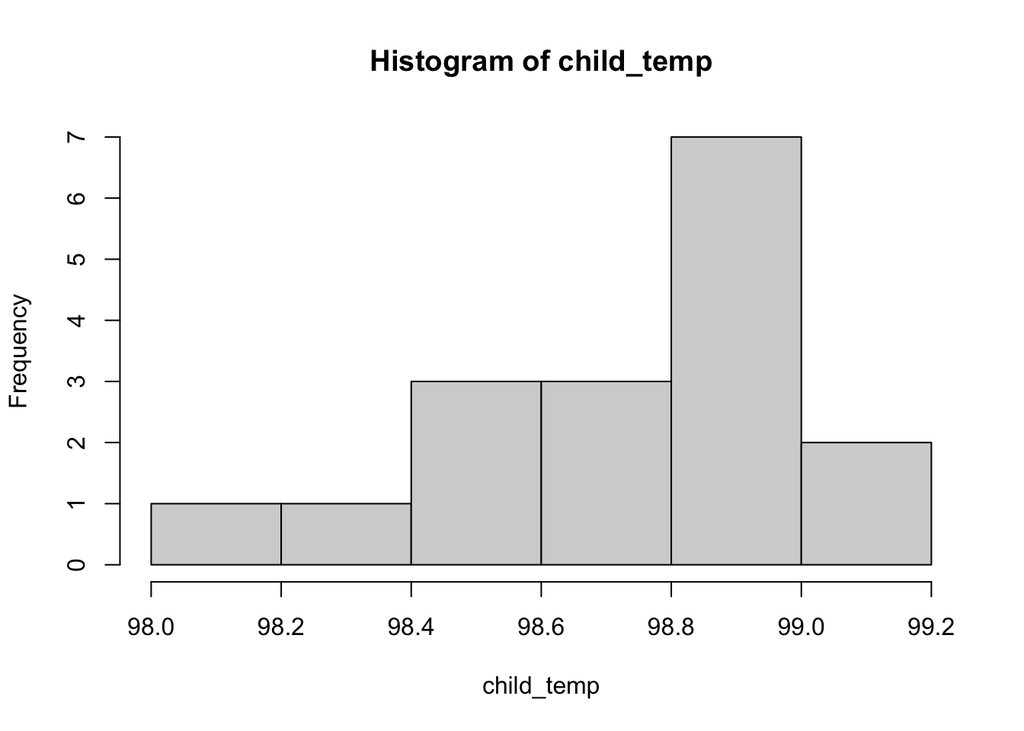

```r
hist(child_temp)
```

```r
#ask if a t-test is applicable here given the distribution of chilren's temperatures in the sample is not symmetric, or if it is still applicable because the larger distribution will be normal
```

Our p-value is 0.01173, which is statistically significant. So we accept the alternative hypothesis that the body temperatures of children in Sodor are greater than the average of 98.6 degrees.

8.24) Normally distributed lengths with unknown mean mu, but sd=4. H0: mu=25 H1: mu>25 aplha=0.05. Sample size is 30. Let’s find the power if mu=27.

```r
distance<-25-qnorm(0.025, 25, 4/sqrt(30))

pnorm(25+distance,27,4/sqrt(30), lower.tail = FALSE)
```

```
## [1] 0.7819067
```

Power is 0.7819067.

8.35) b)

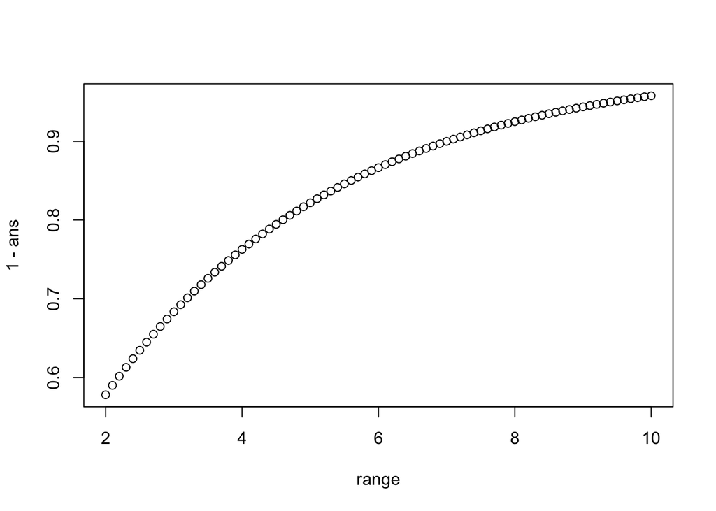

```r
range<-seq(from=2, to=10, by=0.1)
ans<-NULL
for(i in 1:length(range)){
  ans[i]<-(3/4)^(range[i] + 1)
}
plot(range,1-ans)
```